'Sample 1 - Plot manually entered data.ipynb' 8/27/19 D. Candela

# Sample notebook 1: Plotting manually entered data

This Jupyter Notebook illustrates how to plot data that are entered manually. For a very first exercise I would suggest **giving the students a pre-written notebook with a subset of the material here and asking them to paste or type their own data in place of data that is visible the cells below.** This would give them practice in opening and saving JNs and editing and running cells. I would suggest starting out in class with TAs to help.

It could be reasonable to have a whole lab report submitted as a Jupyter Notebook. One way to do this without making too much of a barrier to the students could be to give them the first one or two reports as more or less pre-written JNs with smallish parts for them to modify.

This cell and the cells above are **markdown cells** - they contain arbitary text and can be used to add section headings, explanatory matter, conclusions, etc.

The following cell is a **code cell** which contains Python code that can be executed, and the output produced by that code immediately following. This code cell makes a plot of some data that has been entered directly into the code cell.

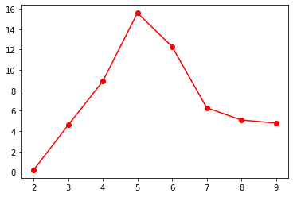

```python
import matplotlib.pyplot as plt
%matplotlib inline

# Enter the data
xs = [2,3,4,5,6,7,8,9]
ys = [0.2,4.6,8.9,15.6,
     12.3,6.3,5.1,4.8]

# Make the plot
plt.plot(xs,ys,'ro-')
plt.show()
```

Notes on the code above:

- The first two commands should be exactly as shown above, and they only need to be executed once after a JN is opened or the kernel is restarted, so they are not in the examples below. (In case you are interested: `import matplotlib.pyplot as plt` makes the plotting commands that start with `plt.` available for use, and `%matplotlib inline` prepares the JN to show graphics right in the notebook.)
- The $x$ and $y$ data are entered as **lists**, which are in square brackets with commas between the numbers. There must be the same number of $x$ and $y$ values.
- The command that makes the plot is `plt.plot(xs,ys,'ro-')`. The third argument `'ro-'` is optional and means make the plot red (`r`) with dots (`o`) connected by a solid line (`-`). At the end of this notebook there are tables showing other possibilities.
- The last command in your plotting code should be `plt.show()`.
- A few picky Python things:
  - A Python command ends at the end of the line, unless there are some brackets not yet closed (as with the list of $y$-values above).
  - Don't put spaces or tabs before the start of a Python command unless you know what you are doing. After the start of the command, you can put spaces wherever you like. (Indents at the start of the line signify code blocks in Python, like `{..}` in C-based languages.)
  - A comment starts with `#` and goes to the end of the line. **You should put comments in your code!**
  - You do need to put round parentheses as shown above for all function calls: `plt.plot(...)`, `plt.show()`.
  - You do need to put quotes arround the format specifier `'ro-'` since it is a string. You can use single or double quotes as you like.
  - Capitalization matters in Python -- `Xs` and `xs` are two different variables. Variables can include numbers and the underscore: `p3`,`n_0`. It's a good habit to avoid upper-case letters in variable names (they are used for class names). **Your variable names should make sense -- don't use `n` for the time $t$!**

### Adding axis labels and titles

**Almost all plots should have axis labels** and a title is usually a good idea as well. You add these things using `plt.xlabel`, `plt.ylabel`, and `plt.title` in any order before the final `plt.show`, as shown by the next code cell.

We don't need to re-enter the $x$ and $y$ values since the variables `xs`, `ys` were already set by executing the first code cell above. But we do need a new `plt.plot` command to make a new plot:

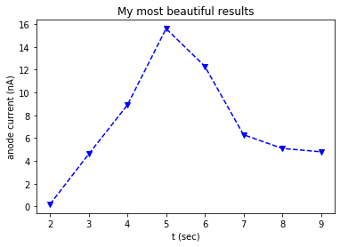

```python
# Redo the plot with the data entered above
plt.plot(xs,ys,'bv--')

# Add some labels before showing it
plt.xlabel('t (sec)')
plt.ylabel('anode current (nA)')
plt.title('My most beautiful results')

plt.show()
```

### Log plots

To plot the data on log axes, include the statements `plt.xscale('log')` and/or `plt.yscale('log')`:

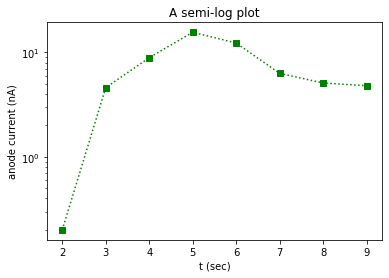

```python
# Re-do the plot, making the y-axis logarithmic
plt.plot(xs,ys,'gs:')
plt.yscale('log')

plt.xlabel('t (sec)')
plt.ylabel('anode current (nA)')
plt.title('A semi-log plot')
plt.show()
```

### Two or more plots on the same axes

To make several plots on the same axes, define more sets of $x$ and $y$ values and include more than one `plt.plot` command. If the $x$ values are the same for both data sets, you can use the same list of $x$'s for both `plt.plot` commands.

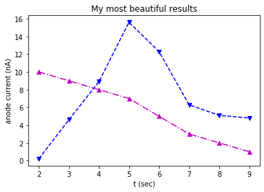

```python
# Enter a second set of y values
y2s = [10,9,8,7,5,3,2,1]

plt.plot(xs,ys,'bv--')  # plot original x's and y's
plt.plot(xs,y2s,'m^-.') # plot original x's with the new y's

plt.xlabel('t (sec)')
plt.ylabel('anode current (nA)')
plt.title('My most beautiful results')
plt.show()
```

### Adding a legend

To add a legend that shows what the various curves are, you must do two things:

- Each `plt.plot` command must include `label='thing to print'`
- You must include the command `plt.legend()` after the `plt.plot` commands:

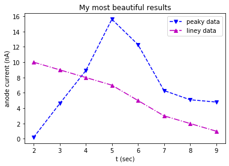

```python
# Re-do the two plots, using label='..' to supply legend text
plt.plot(xs,ys,'bv--',label='peaky data')
plt.plot(xs,y2s,'m^-.',label='liney data')
plt.legend()  # this is needed to make the legend show up

plt.xlabel('t (sec)')
plt.ylabel('anode current (nA)')
plt.title('My most beautiful results')
plt.show()
```

### Picking line and symbol styles and colors for plots

The format strings (`'bv--'` and `'m^-.'` in the example immediately above) can specify a color, a line style, and a marker style; all three are optional and they can be in any order. Here are the line styles:

- `-` solid line
- `--` dashed line
- `-.` dash-dot line
- `:` dotted line

Here are the marker styles:

- `.` point
- `,` pixel
- `o` circle
- `v` triangle_down
- `^` triangle_up
- `<` triangle_left
- `>` triangle_right
- `1` tri_down
- `2` tri_up
- `3` tri_left
- `4` tri_right
- `s` square
- `p` pentagon
- `*` star
- `h` hexagon1
- `H` hexagon2
- `+` plus
- `x` x
- `D` diamond
- `d` thin_diamond
- `|` vline
- `_` hline

Here are the colors:

- `b` blue
- `g` green
- `r` red
- `c` cyan
- `m` magenta
- `y` yellow
- `k` black
- `w` white